# Job Recommendation System

#### Importing necessary packages:

```python
import pandas as pd
import numpy as np

import re
import string
import nltk
nltk.download('punkt')
nltk.download('stopwords')
nltk.download('wordnet')

from nltk.corpus import stopwords
from nltk.tokenize import word_tokenize
from nltk.stem import WordNetLemmatizer
from wordcloud import WordCloud
from collections import Counter
from langdetect import detect
from word2number import w2n

from sklearn.decomposition import TruncatedSVD
from sklearn.preprocessing import Normalizer
from sklearn.pipeline import make_pipeline
from sklearn.cluster import DBSCAN

from sklearn.feature_extraction.text import CountVectorizer, TfidfTransformer,TfidfVectorizer
from sklearn.metrics.pairwise import cosine_similarity
from sklearn.metrics.pairwise import linear_kernel

from sklearn.neighbors import NearestNeighbors
import matplotlib.pyplot as plt
import numpy as np

import webbrowser
import fitz
import time

import matplotlib.pyplot as plt
import seaborn as sns

import pickle

import gensim
from gensim import corpora, models
from gensim.models.ldamulticore import LdaMulticore
from gensim.utils import simple_preprocess
from gensim.models import CoherenceModel

import pyLDAvis
import pyLDAvis.gensim_models as gensimvis
pyLDAvis.enable_notebook()

import multiprocessing

num_processors = multiprocessing.cpu_count()
num_processors

workers = num_processors-1

import warnings
warnings.filterwarnings('ignore')

sns.set()
%matplotlib inline
```

## Reading Job Postings dataset:

```python
job_postings = pd.read_csv(r"C:\Users\nihar\Desktop\DATA MINING\Final Project\job_postings.csv")
job_postings.info()
```

```
<class 'pandas.core.frame.DataFrame'>
RangeIndex: 33246 entries, 0 to 33245
Data columns (total 28 columns):
 #   Column                      Non-Null Count  Dtype
---  ------                      --------------  -----
 0   job_id                      33246 non-null  int64
 1   company_id                  32592 non-null  float64
 2   title                       33246 non-null  object
 3   description                 33245 non-null  object
 4   max_salary                  11111 non-null  float64
 5   med_salary                  2241 non-null   float64
 6   min_salary                  11111 non-null  float64
 7   pay_period                  13352 non-null  object
 8   formatted_work_type         33246 non-null  object
 9   location                    33246 non-null  object
```

[output cut: 20 more lines]

```python
job_postings.isna().sum()
```

```
job_id                            0
company_id                      654
title                             0
description                       1
max_salary                    22135
med_salary                    31005
min_salary                    22135
pay_period                    19894
formatted_work_type               0
location                          0
applies                       17008
original_listed_time              0
remote_allowed                28444
views                          7360
job_posting_url                   0
application_url               12250
application_type                  0
expiry                            0
closed_time                   32074
formatted_experience_level     9181
skills_desc                   32909
listed_time                       0
posting_domain                13558
sponsored                         0
work_type                         0
currency                      19894
compensation_type             19894
scraped                           0
dtype: int64
```

```python
job_postings.shape
```

```
(33246, 28)
```

### Job description is a major part of the job recommendation assistant so the row with na description can be dropped.

```python
job_postings = job_postings.dropna(subset = ['description'])
```

# Data Cleaning

## Salary Cleaning

```python
job_postings1 = job_postings[job_postings['work_type'].isin(['FULL_TIME', 'INTERNSHIP'])]
```

```python
job_postings1.shape
```

```
(27127, 28)
```

```python
job_postings.shape
```

```
(33245, 28)
```

### 1. Converting salary into yearly salary format

```python
job_postings1 = job_postings1[job_postings1['pay_period'].isin(['MONTHLY', 'YEARLY', 'HOURLY', 'WEEKLY']) | job_postings1['pay_period'].isnull()]

# Conversion factors to yearly salary based on American salary standards
conversion_factors = {
    'MONTHLY': 12,
    'YEARLY': 1,
    'HOURLY': 2080,  # Assuming a 40-hour work week and 52 weeks in a year
    'WEEKLY': 52
}

# Applying conversion for non-null numeric values in 'max_salary', 'med_salary', and 'min_salary' columns
for column in ['max_salary', 'med_salary', 'min_salary']:
    for period, factor in conversion_factors.items():
        mask = job_postings1['pay_period'] == period
        job_postings1.loc[mask, column] = job_postings1.loc[mask, column].apply(lambda x: x*factor if pd.notnull(x) else x)
```

### 2. Combine 3 salary columns to 1

```python
job_postings1['annual_salary'] = np.where(job_postings1['max_salary'].notna() & job_postings1['min_salary'].notna(),
                        (job_postings1['max_salary'] + job_postings1['min_salary']) / 2,
                        np.where(job_postings1['med_salary'].notna(),
                                 job_postings1['med_salary'],
                                 np.nan))
```

```python
job_postings1 = job_postings1[job_postings1['annual_salary'] <= 1000000]
```

### Explore Relationship between experience level and salary

```python
df_salary_exp = job_postings1.dropna(subset=['annual_salary', 'formatted_experience_level'])
```

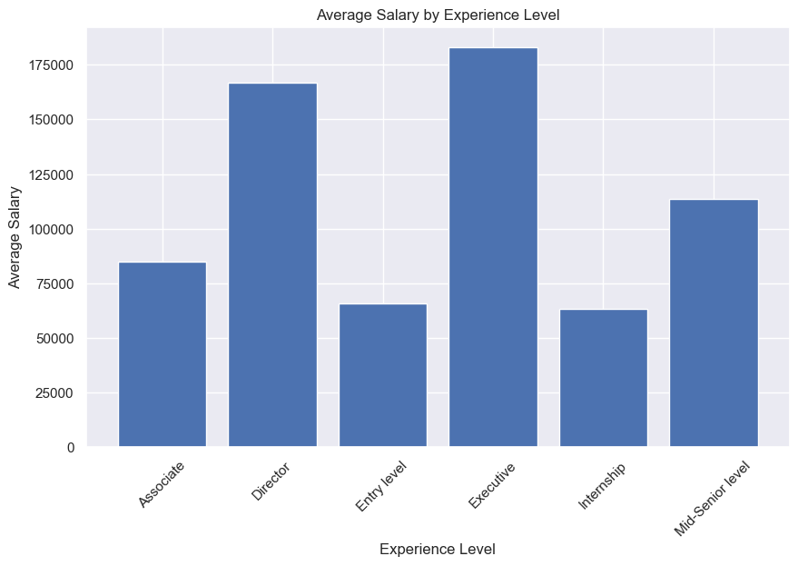

```python
avg_salary_by_exp_level = df_salary_exp.groupby('formatted_experience_level')['annual_salary'].mean().reset_index()

# Now let's plot the histogram for the average salary by experience level

plt.figure(figsize=(10, 6))
plt.bar(avg_salary_by_exp_level['formatted_experience_level'], avg_salary_by_exp_level['annual_salary'])
plt.xlabel('Experience Level')
plt.ylabel('Average Salary')
plt.title('Average Salary by Experience Level')
plt.xticks(rotation=45)
plt.show()
```

```python
df_salary_exp = job_postings1.dropna(subset=['annual_salary', 'formatted_experience_level'])
```

```python
df_salary_exp['formatted_experience_level'] = df_salary_exp['formatted_experience_level'].replace({
    'Director': 'Director Level',
    'Executive': 'Executive Level',
    'Mid-Senior level': 'Senior Level',
    'Associate': 'Junior level'
})
```

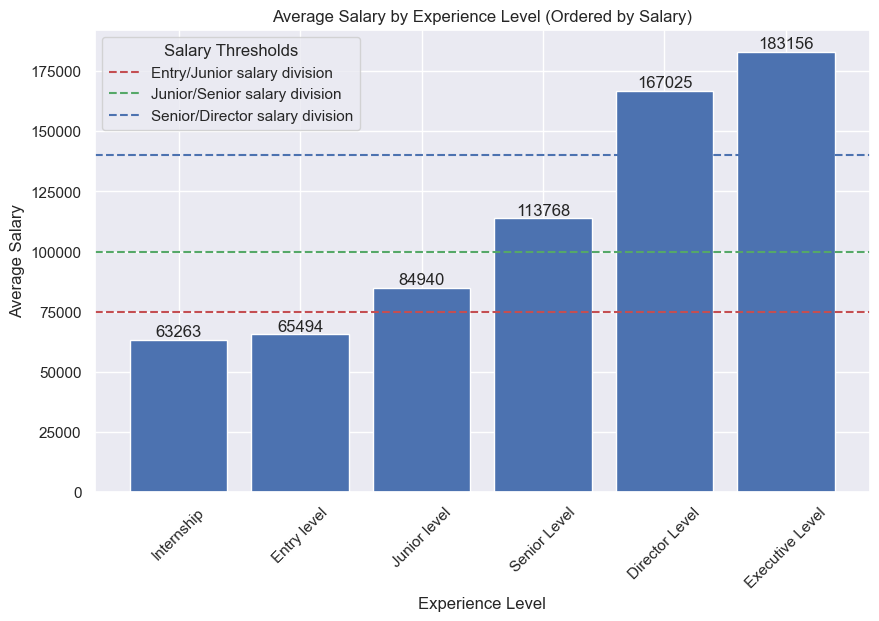

```python
avg_salary_by_exp_level = df_salary_exp.groupby('formatted_experience_level')['annual_salary'].mean().reset_index()
avg_salary_by_exp_level_sorted = avg_salary_by_exp_level.sort_values('annual_salary', ascending=True)

# plot the histogram for the average salary by experience level
plt.figure(figsize=(10, 6))
bars = plt.bar(avg_salary_by_exp_level_sorted['formatted_experience_level'], avg_salary_by_exp_level_sorted['annual_salary'])

plt.xlabel('Experience Level')
plt.ylabel('Average Salary')
plt.title('Average Salary by Experience Level (Ordered by Salary)')

for bar in bars:
    yval = bar.get_height()
    plt.text(bar.get_x() + bar.get_width()/2, yval + 1, round(yval), ha='center', va='bottom')

plt.axhline(y=75000, color='r', linestyle='--', label='Entry/Junior salary division')
plt.axhline(y=100000, color='g', linestyle='--', label='Junior/Senior salary division')
plt.axhline(y=140000, color='b', linestyle='--', label='Senior/Director salary division')

plt.legend(title="Salary Thresholds")

plt.xticks(rotation=45)
plt.show()
```

We can use salary to fill missing job level data:

Salaries below 75000 are entry level jobs;

Salaries between 75000 and 100000 are junior level jobs;

Salaries between 100000 and 140000 are senior level jobs;

Salaries above 140000 are director level jobs

## Transform location to city

```python
job_postings1['city'] = job_postings1['location'].apply(lambda x: x.split(',')[0])
job_postings1 = job_postings1.drop(columns=['location'])
```

```python
job_postings1 = job_postings1.drop(columns=['med_salary', 'min_salary', 'max_salary', 'pay_period', 'scraped', 'compensation_type', 'currency', 'sponsored', 'posting_domain', 'listed_time', 'skills_desc', 'closed_time', 'expiry', 'application_type', 'views', 'original_listed_time', 'applies'])
```

# EDA

## 1. Which city contains jobs with highest pay? (Average salary)

```python
average_salary_by_city = job_postings1.groupby('city')['annual_salary'].mean().reset_index()

# Adding the total count of job openings per city
average_salary_by_city['job_openings_count'] = average_salary_by_city['city'].map(job_postings1['city'].value_counts())

average_salary_by_city['annual_salary'] = average_salary_by_city['annual_salary'].round(2)

average_salary_by_city[average_salary_by_city['job_openings_count']>=5].sort_values('annual_salary', ascending=False)
```

|  | city | annual_salary | job_openings_count |
| --- | --- | --- | --- |
| 600 | Foster City | 230021.94 | 9 |
| 1276 | Newtown Square | 195248.00 | 5 |
| 393 | Cupertino | 192418.00 | 10 |
| 1708 | South San Francisco | 191725.00 | 8 |
| 1615 | Santa Barbara County | 181250.00 | 6 |
| ... | ... | ... | ... |
| 623 | Garden City | 37544.00 | 5 |
| 1796 | Temple | 37452.48 | 5 |
| 969 | Layton | 36763.33 | 6 |
| 1389 | Park City | 36605.00 | 8 |
| 1207 | Mount Horeb | 35978.06 | 7 |

428 rows × 3 columns

## 2. Which city has the most job opportunities?

```python
average_salary_by_city.sort_values('job_openings_count', ascending=False).head(10)
```

|  | city | annual_salary | job_openings_count |
| --- | --- | --- | --- |
| 1865 | United States | 119626.94 | 707 |
| 1265 | New York | 121586.16 | 584 |
| 1026 | Los Angeles | 110865.47 | 251 |
| 1266 | New York City Metropolitan Area | 122865.19 | 178 |
| 1643 | Seattle | 123811.35 | 167 |
| 1591 | San Francisco | 140303.13 | 165 |
| 429 | Denver | 92024.85 | 159 |
| 308 | Chicago | 114086.02 | 129 |
| 1586 | San Diego | 105069.45 | 128 |
| 86 | Austin | 107927.40 | 128 |

## 3. Top-pay / Most opportunity industries

```python
industries = pd.read_csv("industries.csv")
job_industries = pd.read_csv("job_industries.csv")
```

```python
# Merging DataFrames
job_id_industry = pd.merge(job_industries, industries, on='industry_id', how='left')
job_postings1 = pd.merge(job_postings1, job_id_industry, on='job_id', how='left')

# Renaming 'industry_name' to 'industry'
job_postings1.rename(columns={'industry_name': 'industry'}, inplace=True)
```

```python
average_salary_by_industry = job_postings1.groupby('industry')['annual_salary'].mean().reset_index()

# Adding the total count of job openings per city
average_salary_by_industry['job_openings_count'] = average_salary_by_industry['industry'].map(job_postings1['industry'].value_counts())

average_salary_by_industry['annual_salary'] = average_salary_by_industry['annual_salary'].round(2)
average_salary_by_industry[average_salary_by_industry['job_openings_count']>=5].sort_values('annual_salary', ascending=False)
```

|  | industry | annual_salary | job_openings_count |
| --- | --- | --- | --- |
| 26 | Capital Markets | 202193.10 | 29 |
| 21 | Book and Periodical Publishing | 173091.06 | 73 |
| 87 | Information Services | 172822.51 | 158 |
| 32 | Computer Networking Products | 171975.96 | 51 |
| 91 | International Trade and Development | 169458.65 | 13 |
| ... | ... | ... | ... |
| 152 | Restaurants | 55538.37 | 171 |
| 62 | Food & Beverages | 52628.16 | 5 |
| 56 | Equipment Rental Services | 52232.46 | 7 |
| 155 | Retail Art Supplies | 45356.00 | 10 |
| 188 | Wholesale Food and Beverage | 40976.00 | 5 |

141 rows × 3 columns

```python
average_salary_by_industry.sort_values('job_openings_count', ascending=False).head(10)
```

|  | industry | annual_salary | job_openings_count |
| --- | --- | --- | --- |
| 80 | Hospitals and Health Care | 95706.61 | 1008 |
| 168 | Staffing and Recruiting | 94745.15 | 940 |
| 84 | IT Services and IT Consulting | 119453.26 | 903 |
| 61 | Financial Services | 120986.77 | 849 |
| 164 | Software Development | 144305.27 | 719 |
| 170 | Technology, Information and Internet | 145786.50 | 508 |
| 153 | Retail | 64674.29 | 398 |
| 35 | Construction | 95319.69 | 383 |
| 89 | Insurance | 97895.09 | 339 |
| 102 | Manufacturing | 80489.49 | 302 |

## 3. Top-pay company in IT industry

```python
companies = pd.read_csv("companies.csv")
```

```python
job_it = pd.merge(job_postings1[job_postings1['industry'] == 'IT Services and IT Consulting'], companies[['name','company_id']], on='company_id', how='left')

average_salary_by_industry = job_it.groupby('name')['annual_salary'].mean().reset_index().round(2)

# Adding the total count of job openings per city
average_salary_by_industry['job_openings_count'] = average_salary_by_industry['name'].map(job_it['name'].value_counts())

average_salary_by_industry[average_salary_by_industry['job_openings_count']>=5].sort_values('annual_salary', ascending=False)
```

|  | name | annual_salary | job_openings_count |
| --- | --- | --- | --- |
| 95 | Crossover | 314950.00 | 16 |
| 278 | SAP | 221669.00 | 10 |
| 46 | Bloomberg | 215500.00 | 5 |
| 285 | Salesforce | 185275.00 | 12 |
| 157 | Hewlett Packard Enterprise | 182986.36 | 11 |
| 27 | Amazon Web Services (AWS) | 177712.50 | 12 |
| 147 | Globant | 161760.00 | 5 |
| 208 | Mastercard | 157047.62 | 21 |
| 196 | LHH | 140000.00 | 5 |
| 25 | Amazon | 133271.81 | 62 |
| 253 | Publicis Sapient | 118166.67 | 6 |
| 198 | LTI - Larsen & Toubro Infotech | 117833.33 | 6 |
| 122 | Electronic Arts (EA) | 116900.00 | 5 |
| 50 | Booz Allen Hamilton | 114325.34 | 73 |
| 96 | Crowe | 110860.60 | 5 |
| 201 | Leidos | 110716.67 | 21 |
| 187 | Jobot | 101785.71 | 7 |
| 368 | iAppsData Inc. | 100602.67 | 6 |
| 21 | Akkodis | 100208.57 | 7 |
| 212 | Milestone Technologies, Inc. | 89845.00 | 20 |
| 62 | CareFirst BlueCross BlueShield | 85769.00 | 6 |
| 56 | CGI | 85598.80 | 5 |
| 199 | LTIMindtree | 84402.31 | 8 |
| 155 | Hamilton Barnes 🌳 | 84285.71 | 7 |
| 141 | Gainwell Technologies | 82709.09 | 11 |
| 19 | Advantasure | 75130.00 | 6 |
| 242 | Pax8 | 68800.00 | 5 |
| 10 | AT&T | 64640.00 | 5 |
| 111 | EAB | 64000.00 | 5 |
| 79 | Comcast | 50728.44 | 36 |

```python
average_salary_by_industry.sort_values('job_openings_count', ascending=False).head(10)
```

|  | name | annual_salary | job_openings_count |
| --- | --- | --- | --- |
| 50 | Booz Allen Hamilton | 114325.34 | 73 |
| 25 | Amazon | 133271.81 | 62 |
| 79 | Comcast | 50728.44 | 36 |
| 201 | Leidos | 110716.67 | 21 |
| 208 | Mastercard | 157047.62 | 21 |
| 212 | Milestone Technologies, Inc. | 89845.00 | 20 |
| 95 | Crossover | 314950.00 | 16 |
| 285 | Salesforce | 185275.00 | 12 |
| 27 | Amazon Web Services (AWS) | 177712.50 | 12 |
| 157 | Hewlett Packard Enterprise | 182986.36 | 11 |

## Text Pre-processing

##### Text pre-processing of the job description part is crucial in creating the job recommender system.

```python
job_postings.head(5)
```

|  | job_id | company_id | title | description | max_salary | med_salary | min_salary | pay_period | formatted_work_type | location | ... | closed_time | formatted_experience_level | skills_desc | listed_time | posting_domain | sponsored | work_type | currency | compensation_type | scraped |
| --- | --- | --- | --- | --- | --- | --- | --- | --- | --- | --- | --- | --- | --- | --- | --- | --- | --- | --- | --- | --- | --- |
| 0 | 3757940104 | 553718.0 | Hearing Care Provider | Overview\n\nHearingLife is a national hearing ... | NaN | 5250.00 | NaN | MONTHLY | Full-time | Little River, SC | ... | NaN | Entry level | NaN | 1.699090e+12 | careers-demant.icims.com | 0 | FULL_TIME | USD | BASE_SALARY | 1699138101 |
| 1 | 3757940025 | 2192142.0 | Shipping & Receiving Associate 2nd shift (Beav... | Metalcraft of Mayville\nMetalcraft of Mayville... | NaN | NaN | NaN | NaN | Full-time | Beaver Dam, WI | ... | NaN | NaN | NaN | 1.699080e+12 | www.click2apply.net | 0 | FULL_TIME | NaN | NaN | 1699085420 |
| 2 | 3757938019 | 474443.0 | Manager, Engineering | \nThe TSUBAKI name is synonymous with excellen... | NaN | NaN | NaN | NaN | Full-time | Bessemer, AL | ... | NaN | NaN | Bachelor's Degree in Mechanical Engineering pr... | 1.699080e+12 | www.click2apply.net | 0 | FULL_TIME | NaN | NaN | 1699085644 |
| 3 | 3757938018 | 18213359.0 | Cook | descriptionTitle\n\n Looking for a great oppor... | NaN | 22.27 | NaN | HOURLY | Full-time | Aliso Viejo, CA | ... | NaN | Entry level | NaN | 1.699080e+12 | jobs.apploi.com | 0 | FULL_TIME | USD | BASE_SALARY | 1699087461 |
| 4 | 3757937095 | 437225.0 | Principal Cloud Security Architect (Remote) | Job Summary\nAt iHerb, we are on a mission to ... | 275834.0 | NaN | 205956.0 | YEARLY | Full-time | United States | ... | NaN | Mid-Senior level | NaN | 1.699090e+12 | careers.iherb.com | 0 | FULL_TIME | USD | BASE_SALARY | 1699085346 |

5 rows × 28 columns

```python
job_postings.shape
```

```
(33245, 28)
```

```python
job_postings['company_id'] = job_postings['company_id'].fillna(0)
job_postings['company_id'] = job_postings['company_id'].astype(int)
```

#### Companies data:

```python
cmp = pd.read_csv(r"companies.csv")
cmp.head()
cmp.dtypes
```

```
company_id        int64
name             object
description      object
company_size    float64
state            object
country          object
city             object
zip_code         object
address          object
url              object
dtype: object
```

```python
cmp.head()
```

|  | company_id | name | description | company_size | state | country | city | zip_code | address | url |
| --- | --- | --- | --- | --- | --- | --- | --- | --- | --- | --- |
| 0 | 1009 | IBM | At IBM, we do more than work. We create. We cr... | 7.0 | NY | US | Armonk, New York | 10504 | International Business Machines Corp. | https://www.linkedin.com/company/ibm |
| 1 | 1016 | GE HealthCare | Every day millions of people feel the impact o... | 7.0 | 0 | US | Chicago | 0 | - | https://www.linkedin.com/company/gehealthcare |
| 2 | 1021 | GE Power | GE Power, part of GE Vernova, is a world energ... | 7.0 | NY | US | Schenectady | 12345 | 1 River Road | https://www.linkedin.com/company/gepower |
| 3 | 1025 | Hewlett Packard Enterprise | Official LinkedIn of Hewlett Packard Enterpris... | 7.0 | Texas | US | Houston | 77389 | 1701 E Mossy Oaks Rd Spring | https://www.linkedin.com/company/hewlett-packa... |
| 4 | 1028 | Oracle | We’re a cloud technology company that provides... | 7.0 | Texas | US | Austin | 78741 | 2300 Oracle Way | https://www.linkedin.com/company/oracle |

```python
cmp.shape
```

```
(11361, 10)
```

```python
# Merge the two DataFrames on the company_id column
job_postings = pd.merge(job_postings, cmp[['company_id', 'name']], on='company_id', how='left')

# Rename the 'name' column to 'company_name'
job_postings.rename(columns={'name': 'company_name'}, inplace=True)
```

```python
job_postings.isna().sum()
```

```
job_id                            0
company_id                        0
title                             0
description                       0
max_salary                    22134
med_salary                    31004
min_salary                    22134
pay_period                    19893
formatted_work_type               0
location                          0
applies                       17007
original_listed_time              0
remote_allowed                28443
views                          7360
job_posting_url                   0
application_url               12249
application_type                  0
expiry                            0
closed_time                   32073
formatted_experience_level     9180
skills_desc                   32908
listed_time                       0
posting_domain                13557
sponsored                         0
work_type                         0
currency                      19893
compensation_type             19893
scraped                           0
company_name                    705
dtype: int64
```

### If we don't have the company_name what will we recommend hence, dropping the rows with missing values in the company_name column.

```python
job_postings = job_postings.dropna(subset = ['company_name'])
```

```python
job_postings.shape
```

```
(32540, 29)
```

```python
selected_columns = ['job_id', 'company_id', 'title', 'description',
                    'formatted_work_type', 'location', 'job_posting_url', 'company_name']

job_postings = job_postings[selected_columns]
job_postings.head()
```

|  | job_id | company_id | title | description | formatted_work_type | location | job_posting_url | company_name |
| --- | --- | --- | --- | --- | --- | --- | --- | --- |
| 0 | 3757940104 | 553718 | Hearing Care Provider | Overview\n\nHearingLife is a national hearing ... | Full-time | Little River, SC | https://www.linkedin.com/jobs/view/3757940104/... | HearingLife |
| 1 | 3757940025 | 2192142 | Shipping & Receiving Associate 2nd shift (Beav... | Metalcraft of Mayville\nMetalcraft of Mayville... | Full-time | Beaver Dam, WI | https://www.linkedin.com/jobs/view/3757940025/... | Metalcraft of Mayville, Inc. |
| 2 | 3757938019 | 474443 | Manager, Engineering | \nThe TSUBAKI name is synonymous with excellen... | Full-time | Bessemer, AL | https://www.linkedin.com/jobs/view/3757938019/... | U.S. Tsubaki Power Transmission, LLC |
| 3 | 3757938018 | 18213359 | Cook | descriptionTitle\n\n Looking for a great oppor... | Full-time | Aliso Viejo, CA | https://www.linkedin.com/jobs/view/3757938018/... | Episcopal Communities & Services |
| 4 | 3757937095 | 437225 | Principal Cloud Security Architect (Remote) | Job Summary\nAt iHerb, we are on a mission to ... | Full-time | United States | https://www.linkedin.com/jobs/view/3757937095/... | iHerb, LLC |

```python
job_postings.isna().sum()
```

```
job_id                 0
company_id             0
title                  0
description            0
formatted_work_type    0
location               0
job_posting_url        0
company_name           0
dtype: int64
```

## Text Pre-Processing

### Various functions to preprocess the job description text:

```python
# Function to remove special character "!"#$%&'()*+, -./:;<=>?@[\]^_`{|}~"
def remove_punctuation(text):
    punctuation = string.punctuation + "–"
    return re.sub(f"[{re.escape(punctuation)}]", " ", text)

# Function to remove Digits
def remove_digits(text):
    return "".join(filter(lambda char: not char.isdigit(), text))

# Function to remove urls
def remove_urls(text):
    url_pattern = r'https?://\S+|www\.\S+|\b\S+\.(com|net|org|info|edu)\b'
    return re.sub(url_pattern, '', text)

# Function to remove HTML Tag
def remove_html(text):
    html_pattern = re.compile("<.*?>")
    return html_pattern.sub(r"", text)

#Function to remove email texts
def remove_emails(text):
    return re.sub(r"\S+@\S+", "", text)

# Tokenize the description column
def tokenize_text(text):
    return word_tokenize(text)

#Function to convert the tokens into lower strings
def convert_to_lower_case(tokens):
    return [token.lower() for token in tokens]

#Function to remove single alphabets, repeat words and non-alphanumeric characters
def remove_single_alphabets(tokens):
    # Remove single alphabets
    tokens = [token for token in tokens if len(token) > 1]

    return tokens

# Function to expand contractions
def expand_contractions(tokens):
    contractions_dict = {
    "ain't": "is not","aren't": "are not",
    "can't": "cannot",    "'cause": "because",
    "could've": "could have",    "couldn't": "could not",
    "didn't": "did not",    "doesn't": "does not",
    "don't": "do not",    "hadn't": "had not",
    "hasn't": "has not",    "haven't": "have not",
    "he'd": "he would",    "he'll": "he will",
    "he's": "he is",    "how'd": "how did",
    "how'd'y": "how do you",    "how'll": "how will",
    "how's": "how is",    "I'd": "I would",
    "I'd've": "I would have",    "I'll": "I will",
    "I'll've": "I will have",    "I'm": "I am",
    "I've": "I have",    "i'd": "i would",
    "i'd've": "i would have",    "i'll": "i will",
    "i'll've": "i will have",    "i'm": "i am",
    "i've": "i have",    "isn't": "is not",
    "it'd": "it would",    "it'd've": "it would have",
    "it'll": "it will",    "it'll've": "it will have",
    "it's": "it is",    "let's": "let us",
    "ma'am": "madam",    "mayn't": "may not",
    "might've": "might have",    "mightn't": "might not",
    "mightn't've": "might not have",    "must've": "must have",
    "mustn't": "must not",    "mustn't've": "must not have",
    "needn't": "need not",    "needn't've": "need not have",
    "o'clock": "of the clock",    "oughtn't": "ought not",
    "oughtn't've": "ought not have",    "shan't": "shall not",
    "sha'n't": "shall not",    "shan't've": "shall not have",
    "she'd": "she would",    "she'd've": "she would have",
    "she'll": "she will",    "she'll've": "she will have",
    "she's": "she is",    "should've": "should have",
    "shouldn't": "should not",    "shouldn't've": "should not have",
    "so've": "so have",    "so's": "so as",
    "this's": "this is",    "that'd": "that would",
    "that'd've": "that would have",    "that's": "that is",
    "there'd": "there would",    "there'd've": "there would have",
    "there's": "there is",    "here's": "here is",
    "they'd": "they would",    "they'd've": "they would have",
    "they'll": "they will",    "they'll've": "they will have",
    "they're": "they are",    "they've": "they have",
    "to've": "to have",    "wasn't": "was not","we'd": "we would",
    "we'd've": "we would have",    "we'll": "we will",
    "we'll've": "we will have",    "we're": "we are",
    "we've": "we have",    "weren't": "were not",
    "what'll": "what will",    "what'll've": "what will have",
    "what're": "what are",    "what's": "what is",
    "what've": "what have",    "when's": "when is",
    "when've": "when have",    "where'd": "where did",
    "where's": "where is",    "where've": "where have",
    "who'll": "who will",    "who'll've": "who will have",
    "who's": "who is",    "who've": "who have",
    "why's": "why is","why've": "why have","will've": "will have",
    "won't": "will not","won't've": "will not have","would've": "would have","wouldn't": "would not",
    "wouldn't've": "would not have","y'all": "you all","y'all'd": "you all would","y'all'd've": "you all would have","y'all're": "you all are",
    "y'all've": "you all have","you'd": "you would","you'd've": "you would have","you'll": "you will",
    "you'll've": "you will have","you're": "you are","you've": "you have","u.s": "america","e.g": "for example",}
    expanded_tokens = []
    for token in tokens:
        if token in contractions_dict:
            expanded_tokens.extend(contractions_dict[token].split())
        else:
            expanded_tokens.append(token)
    return expanded_tokens

# Function to remove stop words
def remove_combined_stop_words(tokens):

    # Get a set of English stop words
    english_stop_words = set(stopwords.words('english'))

    # Custom stop words
    custom_stop_words = [
        "job", "role", "position", "responsibility", "responsibilities", "duties", "duty", "ability", 'six', 'seven', 'eight', 'nine'
        "requirement", "requirements", "qualification", "qualifications", "description", 'one', 'two', 'three', 'four', 'five', 'zero'
        "descriptions", "candidate", "candidates", "applicant", "applicants", "opportunity", "low", "high", "lower", "lowest",
        "opportunities", "team", "teams", "work", "working", "employee", "employees", "largest", "higher", "highest", "basic",
        "employer", "employers", "company", "companies", "location", "locations", "american", "us", "registry", "large", "larger",
        "department", "departments", "report", "reports", "reporting", "benefit", "benefits", "technologist", "small", "smaller",
        "compensation", "salary", "experience", "experienced", "year", "years", "gender", "minimum", "maximum", "tech", "technology",
        "race", "color", "sex", "orientation", "sexual", "religion", "national", "identify", "type", "types", "hire", "must", "obtain",
        "veteran", "nation", "including", "required", "disability", "regard", "skills", "skill", "abilities", "month", "year", "fte",
    ]

    # Combine English and custom stop words
    combined_stop_words = english_stop_words.union(custom_stop_words)

    return [token for token in tokens if token not in combined_stop_words]

#Lemmatizer to bring the tokens to their root word
def lemmatize_tokens(tokens):

    # Initialize the WordNet Lemmatizer
    lemmatizer = WordNetLemmatizer()
    return [lemmatizer.lemmatize(token) for token in tokens]
```

```python
# Function for text-preprocessing

def preprocess_text(text):

    #Remove urls
    text_wout_urls = remove_urls(text)

    #Remove html
    text_wout_html = remove_html(text_wout_urls)

    #Remove emails
    text_wout_email = remove_emails(text_wout_html)

    #Remove the punctuations
    text_wout_punc = remove_punctuation(text_wout_email)

    #Remove digits
    text_wout_digits = remove_digits(text_wout_punc)

    # Tokenize the text
    tokens = tokenize_text(text_wout_digits)

    # Convert tokens to lowercase
    lower_tokens = convert_to_lower_case(tokens)

    #Remove digits in words, single alphabets, non-alphanumeric char
    tokens_wout_salph = remove_single_alphabets(lower_tokens)

    # Expand contractions
    expanded_tokens = expand_contractions(tokens_wout_salph)

    # Remove stop words
    no_stop_words_tokens = remove_combined_stop_words(expanded_tokens)

    # Lemmatize the tokens
    lemmatized_tokens = lemmatize_tokens(no_stop_words_tokens)

    # Rejoin the tokens into a processed string
    processed_text = ' '.join(lemmatized_tokens)

    return processed_text
```

```python
job_postings['processed_description'] = job_postings['description'].apply(lambda x: preprocess_text(x))
```

## Skill Bank:

```python
skill_bank = [
    "python", "java", "c++", "javascript", "php", "ruby", "swift", "r", "kotlin", "go", "rust",
    "scala", "groovy", "perl", "haskell", "erlang", "lisp", "prolog", "cobol", "fortran",
    "assembly", "matlab", "objective-c", "smalltalk", "visual basic", "c#", "dart", "typescript",
    "elixir", "ada", "f#", "lua", "abap", "pascal", "delphi", "julia",
    "clojure", "ocaml", "swift", "elm", "coffeescript", "racket", "nim", "crystal", "hack",
    "vala", "django", "spring", "react", "vue.js", "angular", "laravel", "express", "flask",
    "rails", "ember", "meteor", "nestjsx", "phoenix", "hapi", "koa", "adonisjs", "sails.js",
    "loopback", "catalyst", "struts", "jsf", "grails", "dropwizard", "spark",
    "asp.net mvc", "nancy", "sinatra", "bottle", "falcon", "martini", "iris", "revel", "gorilla",
    "echo", ".net framework", "qt", "swing", "javafx", "wxpython", "tkinter", "pyqt", "kivy",
    "tornado", "pyramid", "web2py", "turbgears", "grok", "zope", "mysql", "postgresql",
    "mongodb", "oracle", "sql server", "mariadb", "redis", "cassandra", "elasticsearch",
    "hadoop", "hive", "spark", "neo4j", "couchdb", "nosql", "sql", "sqlite", "access",
    "firebird", "informix", "sybase", "teradata", "db2", "ibm db2", "microsoft access",
    "amazon relational database service", "amazon aurora", "amazon redshift",
    "amazon elasticache", "amazon dynamodb", "amazon s3",
    "amazon ec2", "amazon vpc", "amazon lambda", "amazon api gateway", "amazon cloudfront", "amazon route 53",
    "google cloud sql", "google cloud storage", "google cloud bigtable", "google bigquery",
    "google compute engine", "google kubernetes engine", "google app engine",
    "google cloud functions", "linux", "windows", "macos", "freebsd", "openbsd", "solaris",
    "chromeos", "android", "ios", "ubuntu", "debian", "centos", "fedora", "red hat", "suse",
    "gentoo", "slackware", "arch linux", "manjaro", "linux mint", "zorin os", "elementary os",
    "solus", "mx linux", "kubuntu", "lubuntu", "xubuntu", "budgie", "kde neon", "pclinuxos",
    "puppy linux", "antix", "damn small linux", "knoppix", "slax", "porteus", "peppermint os",
    "bodhi linux", "raspbian os", "tails", "qubes os", "whonix", "kali linux", "parrot security os",
    "blackarch linux", "tcp/ip", "http", "dns", "dhcp", "ftp", "vpn", "ssh", "telnet", "snmp",
    "wi-fi", "bluetooth", "ethernet", "5g", "cellular networks", "satellite communications",
    "network topology", "network protocols", "firewalls",
    "intrusion detection systems","ids",  "intrusion prevention systems", "ips", "network security",
    "network monitoring", "network troubleshooting", "network design", "network administration",
    "wireless networking", "software-defined networking", "sdn", "network virtualization",
    "voice over ip", "network automation", "ssl", "tls", "encryption", "firewalls",
    "intrusion detection systems", "penetration testing", "risk management", "authentication",
    "authorization", "cryptography", "hashing", "biometrics", "security protocols", "security architecture", "security best practices", "security awareness", "security compliance",
    "security auditing", "security incident response", "disaster recovery", "vulnerability assessment",
    "malware analysis", "digital forensics", "ethical hacking", "secure coding",
    "identity and access management", "privileged access management",
    "data loss prevention", "dlp", "endpoint security", "cloud security", "mobile security",
    "devsecops", "regression analysis", "time series analysis", "anova", "t-test",
    "chi-squared test", "mann-whitney u test", "kruskal-wallis test", "kaplan-meier estimator",
    "cox proportional hazards model", "survival analysis", "bayesian statistics",
    "nonparametric statistics", "multivariate analysis", "experimental design", "data visualization",
    "statistical inference", "hypothesis testing", "confidence intervals", "p-values", "correlation",
    "causation", "statistical modeling", "spss", "sas", "stata", "minitab",
    "k-means clustering", "association rule mining", "decision tree learning", "naive bayes classifier",
    "support vector machines", "random forest", "gradient boosting", "anomaly detection",
    "dimensionality reduction", "feature engineering", "data cleaning", "data preparation",
    "data wrangling", "data exploration", "data visualization", "text mining", "web scraping",
    "sentiment analysis", "topic modeling", "social network analysis", "market basket analysis",
    "time series forecasting", "supervised learning", "unsupervised learning", "reinforcement learning",
    "deep learning", "natural language processing", "computer vision", "speech recognition",
    "image recognition", "robotics", "machine learning algorithms", "machine learning models",
    "machine learning libraries", "machine learning frameworks", "machine learning tools",
    "machine learning applications", "linear regression", "logistic regression", "decision trees",
    "support vector machines", "svm", "random forests", "gradient boosting machines", "gbm",
    "k-nearest neighbors", "knn", "naive bayes", "neural networks", "feature engineering",
    "model selection", "hyperparameter tuning", "model evaluation", "machine learning pipelines",
    "convolutional neural networks", "cnn", "recurrent neural networks", "rnn",
    "generative adversarial networks", "gan", "transformers", "reinforcement learning",
    "deep q-learning", "policy gradients", "actor-critic methods", "monte carlo tree search",
    "deep learning algorithms", "deep learning models",

    # Deep Learning
    "deep learning frameworks", "deep learning libraries", "deep learning tools",
    "deep learning applications",

    # Computer Vision
    "computer vision", "image classification", "object detection", "image segmentation",
    "image generation", "facial recognition", "optical character recognition",
    "scene understanding", "motion tracking", "augmented reality", "virtual reality",
    "pose estimation", "3d reconstruction", "image processing", "video analysis",
    "computer vision libraries", "opencv", "pillow", "scikit-image", "deep learning for computer vision",
```

```python
    # Natural Language Processing
    "natural language processing", "machine translation", "text summarization", "speech recognition",
    "sentiment analysis", "time series forecasting", "sentiment analysis", "named entity recognition",
    "question answering", "chatbots", "information extraction", "natural language generation",
    "topic modeling", "text classification", "word embeddings", "language modeling",
    "part-of-speech tagging", "syntactic parsing", "semantic analysis",
    "natural language understanding", "nlu", "natural language generation", "dialogue systems",
    "computational linguistics",

    # Version Control
    "git", "svn", "mercurial", "cvs", "perforce", "clearcase", "bitbucket", "github", "gitlab",
    "azure devops", "sourceforge", "plastic scm", "beanstalk", "bazaar", "fossil", "monotone",

    # Software Development Methodologies
    "scrum", "kanban", "extreme programming", "lean software development", "crystal clear",
    "feature driven development", "fdd", "behavior driven development", "bdd",
    "test driven development", "tdd", "scaled agile framework", "agile scrum",

    # DevOps and CI/CD
    "devops", "continuous integration/continuous delivery", "selenium", "cypress", "jest",
    "mocha", "karma", "puppeteer", "appium", "cucumber", "robot framework", "serenity bdd",
    "junit", "nunit", "testng", "pytest", "specflow", "unit testing", "integration testing",
    "functional testing", "performance testing", "load testing", "stress testing", "security testing",
    "accessibility testing", "cross-browser testing", "ci/cd", "docker", "kubernetes", "jenkins",
    "travis ci", "circleci", "gitlab ci", "azure devops pipelines", "azure devops releases",
    "ansible", "chef", "puppet", "terraform", "cloudformation", "vagrant", "packer", "saltstack",
    "aws codedeploy", "aws codepipeline", "aws codestar", "infrastructure as code",
    "configuration management", "continuous monitoring", "cloud automation",

    # UX/UI and Marketing
    "user experience", "ux", "user interface", "ui", "usability", "information architecture",
    "interaction design", "visual design", "graphic design", "typography", "color theory", "layout",
    "accessibility", "wireframing", "prototyping", "user research", "user testing", "a/b testing",
    "design sprints", "human-centered design", "seo", "sem", "ppc", "social media marketing",
    "content marketing", "email marketing", "affiliate marketing", "influencer marketing",
    "search engine marketing",    # Marketing
    "digital marketing", "brand marketing", "marketing analytics", "marketing automation",
    "marketing strategy", "market research", "marketing communications", "advertising",
    "public relations", "copywriting", "lead generation", "conversion optimization",
    "customer acquisition", "customer retention", "marketing roi", "crm",

    # Sales
    "lead generation", "sales forecasting", "customer relationship management", "account management",
    "business development", "negotiation", "persuasion", "sales pitch", "cold calling",
    "sales process", "sales funnel", "sales methodology", "sales training", "sales enablement",
    "relationship selling", "consultative selling", "solution selling", "closing techniques",

    # Finance
    "accounting", "financial analysis", "budgeting", "forecasting", "risk management",
    "investment analysis", "financial modeling", "auditing", "tax preparation", "bookkeeping",
    "financial reporting", "financial statements", "financial ratios", "financial planning",
    "financial markets", "corporate finance", "treasury management", "working capital management",
    "capital budgeting", "mergers and acquisitions (m&a)", "private equity", "venture capital",

    # Human Resources
    "hris", "payroll", "talent management", "employee relations", "benefits administration",
    "training and development", "recruitment", "onboarding", "performance management", "compensation",
    "hr analytics", "hr compliance", "hr strategy", "hr leadership", "employee engagement",
    "succession planning", "organizational development", "change management", "labor relations",
    "employment law",

    # Project and Operations Management
    "project management", "supply chain management", "quality assurance", "risk management",
    "lean manufacturing", "six sigma", "process improvement", "productivity", "efficiency",
    "customer service", "operations management", "operations research", "operations strategy",
    "logistics", "inventory management", "procurement", "supply chain optimization",
    "total quality management", "continuous improvement", "kaizen",
    "just-in-time manufacturing",

    # Soft Skills
    "effective communication skills", "teamwork and collaboration skills",
    "presentation and public speaking skills", "skilled negotiation and persuasion",
    "active listening skills", "ability to give and receive feedback", "conflict resolution",
    "meeting facilitation", "cross-cultural communication", "interpersonal skills", "facilitation",
    "coaching", "mentoring",  "networking", "relationship building", "complex problem-solving skills",
    "creative and innovative thinking", "data analysis and interpretation",
    "effective decision-making skills", "risk management and forecasting", "root cause analysis",
    "troubleshooting", "analytical thinking", "critical thinking", "strategic thinking",
    "systems thinking", "ability to learn new information and technologies quickly",
    "adaptability to changing environments", "self-directed learning and development",
    "passion for continuous improvement"

    # Soft Skills (Expanded)
    "ability to learn from mistakes", "openness to new ideas", "growth mindset", "curiosity",
    "intellectual flexibility", "resilience", "responsibility and reliability",
    "time management and organizational skills", "attention to detail and accuracy",
    "high levels of energy and motivation", "positive and proactive attitude", "initiative",
    "persistence", "thoroughness", "integrity", "ethics", "leadership", "self-awareness", "empathy",
    "humility", "professionalism", "dependability",
```

```python
    # General Productivity Software
    "microsoft word", "excel", "powerpoint", "photoshop", "illustrator",
    "specific industry-related software", "adaptability to various software and tools",
    "skill in learning and using new tools", "technological troubleshooting abilities",

    # Collaboration and Management Software
    "project management software", "jira", "asana", "trello",
    "customer relationship management software", "crm",

   # Languages
   "english", "spanish", "french", "german", "mandarin", "japanese", "arabic", "hindi",
   "russian", "portuguese", "korean",

   # Healthcare
   "medical terminology", "patient care", "medical billing and coding", "hipaa compliance",
   "clinical research", "electronic health records", "ehr", "pharmaceutical sales",
   "healthcare administration",

   # Construction
   "construction project management", "building codes", "safety regulations", "blueprint reading",
   "carpentry", "plumbing", "electrical work", "masonry", "hvac",

   # Finance (Expanded)
   "financial modeling", "investment analysis", "portfolio management", "financial reporting",
   "tax regulations", "risk management", "mergers and acquisitions", "corporate finance",
   "financial instruments",

   # Education
   "lesson planning", "classroom management", "student assessment", "differentiated instruction",
   "special education", "educational technology", "learning management systems",

   # Industrial
   "quality control", "lean manufacturing", "six sigma", "supply chain management",
   "safety regulations", "process improvement", "industrial engineering",

   # Service and Retail
   "customer service", "sales techniques", "inventory management", "merchandising",
   "point-of-sale systems", "loss prevention", "supply chain management", "guest service",
   "event planning", "food and beverage management", "front desk operations", "housekeeping",
   "revenue management",

   # Logistics
   "logistics", "supply chain management", "route planning", "vehicle maintenance",
   "safety regulations", "hazardous materials handling", "commercial driver's license",
   "freight forwarding", "warehousing",

   # Law
   "conflict resolution",

   # Non-profit
   "fundraising", "grant writing", "program development", "volunteer management",
   "community outreach", "advocacy", "social impact", "non-profit management", "farming", "agronomy", "crop management", "livestock management", "precision agriculture",
    "agricultural technology", "agricultural economics", "food safety", "sustainability",

    # Energy
    "renewable energy", "solar power", "wind power", "energy efficiency", "power grid management",
    "energy trading", "petroleum engineering", "oil and gas", "nuclear energy", "hydroelectric power",
    "energy policy", "energy economics",

    # Environmental
    "sustainability", "environmental science", "environmental policy", "climate change",
    "pollution control", "waste management", "recycling", "conservation", "environmental law", "ecology",
    "environmental impact assessment", "environmental engineering",

    # Biotechnology
    "bioinformatics", "genetic engineering", "pharmaceuticals", "biomanufacturing", "medical devices",
    "diagnostics", "lab techniques", "drug development", "clinical trials", "biotechnology regulations",

    # Aerospace
    "aeronautical engineering", "aerospace engineering", "flight mechanics", "spacecraft design",
    "propulsion systems", "avionics", "materials science", "satellite systems", "space exploration",

     # Leadership and Personal Development
    "visionary", "strategic", "inspiring", "motivating", "delegation", "mentorship",
    "decision-making", "self-awareness", "self-regulation", "empathy", "social skills", "motivation",
    "persuasion", "negotiation", "networking", "relationship-building", "storytelling",
    "coping mechanisms", "mindfulness", "resilience", "adaptability", "prioritization",
    "organization", "scheduling", "goal-setting", "problem-solving", "creativity", "innovation",
    "initiative", "ability to find solutions",  "out-of-the-box thinking", "brainstorming",
    "ideation", "artistic expression", "adaptability to change", "open-mindedness",
    "willingness to learn", "respect for diversity", "cross-cultural communication",
    "understanding of different perspectives",

    # Blockchain and Crypto
    "cryptocurrencies", "decentralized applications", "smart contracts",
    "distributed ledger technology", "blockchain development", "decentralized web",
    "blockchain integration", "dapp development", "cryptocurrency protocols", "web3 technologies",

    # AI and Embedded Systems
    "machine learning algorithms", "neural networks", "natural language processing", "computer vision",
    "robotics", "ethical ai", "specific ai applications", "embedded systems", "sensor technology",
    "network protocols", "data analytics", "iot security", "smart home devices",

    # Security
    "network security", "vulnerability assessment", "incident response", "penetration testing",
    "ethical hacking", "threat intelligence", "cryptography",

    # Data Visualization
    "data storytelling", "chart design", "infographic creation", "data dashboards",
    "tools like tableau, power bi, d3.js",

     # Geospatial
     "spatial analysis", "mapping", "cartography", "remote sensing", "geospatial data management",
     "software like arcgis, qgis",

     # Game Development
     "unity", "unreal engine",
     "3d modeling", "animation", "game design", "level design", "audio design"


]
```

```python
def count_skills(description, skill_bank):

  words = description.lower().split()
  skills = [skill for skill in words if skill in skill_bank]
  desc_skills = set(skills)
  skill_cnt = len(desc_skills)
  return skill_cnt, desc_skills
```

```python
job_postings['skill_bank'] = job_postings['processed_description'].apply(lambda x: count_skills(x, skill_bank)[1])
job_postings['skill_cnt'] = job_postings['processed_description'].apply(lambda x: count_skills(x, skill_bank)[0])
```

```python
job_postings.isna().sum()
```

```
job_id                   0
company_id               0
title                    0
description              0
formatted_work_type      0
location                 0
job_posting_url          0
company_name             0
processed_description    0
skill_bank               0
skill_cnt                0
dtype: int64
```

```python
job_postings.shape
```

```
(32540, 11)
```

```python
df1 = job_postings.copy()
```

```python
df1.head(5)
```

|  | job_id | company_id | title | description | formatted_work_type | location | job_posting_url | company_name | processed_description | skill_bank | skill_cnt |
| --- | --- | --- | --- | --- | --- | --- | --- | --- | --- | --- | --- |
| 0 | 3757940104 | 553718 | Hearing Care Provider | Overview\n\nHearingLife is a national hearing ... | Full-time | Little River, SC | https://www.linkedin.com/jobs/view/3757940104/... | HearingLife | overview hearinglife hearing care part demant ... | {rust, innovation, leadership, troubleshooting... | 6 |
| 1 | 3757940025 | 2192142 | Shipping & Receiving Associate 2nd shift (Beav... | Metalcraft of Mayville\nMetalcraft of Mayville... | Full-time | Beaver Dam, WI | https://www.linkedin.com/jobs/view/3757940025/... | Metalcraft of Mayville, Inc. | metalcraft mayville metalcraft mayville equal ... | {logistics, housekeeping, motivation, english} | 4 |
| 2 | 3757938019 | 474443 | Manager, Engineering | \nThe TSUBAKI name is synonymous with excellen... | Full-time | Bessemer, AL | https://www.linkedin.com/jobs/view/3757938019/... | U.S. Tsubaki Power Transmission, LLC | tsubaki name synonymous excellence quality dep... | {efficiency, delegation, innovation, leadershi... | 7 |
| 3 | 3757938018 | 18213359 | Cook | descriptionTitle\n\n Looking for a great oppor... | Full-time | Aliso Viejo, CA | https://www.linkedin.com/jobs/view/3757938018/... | Episcopal Communities & Services | descriptiontitle looking great develop profess... | {chef, organization} | 2 |
| 4 | 3757937095 | 437225 | Principal Cloud Security Architect (Remote) | Job Summary\nAt iHerb, we are on a mission to ... | Full-time | United States | https://www.linkedin.com/jobs/view/3757937095/... | iHerb, LLC | summary iherb mission make health wellness acc... | {initiative, encryption, go, organization} | 4 |

```python
df1['skill_cnt'].value_counts()
```

```
skill_cnt
1     5217
2     4933
3     4609
4     3780
0     3299
5     3061
6     2322
7     1759
8     1183
9      792
10     572
11     404
12     245
13     136
14      83
15      44
16      37
17      23
18      13
19       6
22       6
20       4
23       4
26       3
24       2
21       2
31       1
Name: count, dtype: int64
```

## Topic Modeling

```python
bigram = gensim.models.Phrases(job_postings['processed_description'], min_count=5, threshold=100)
trigram = gensim.models.Phrases(bigram[job_postings['processed_description']], threshold=100)
```

```python
job_postings['jd_bigrams'] = [bigram[x] for x in job_postings['processed_description']]
job_postings['jd_trigrams'] = [trigram[bigram[x]] for x in job_postings['processed_description']]
```

```python
# Creating the term dictionary of our courpus, where every unique term is assigned an index.
dictionary = corpora.Dictionary(job_postings['jd_trigrams'])

dictionary.filter_extremes(no_below=20, no_above=0.5)
# Converting list of documents (corpus) into Document Term Matrix using dictionary prepared above.
doc_term_matrix = [dictionary.doc2bow(doc) for doc in job_postings['jd_trigrams']]
```

```python
# supporting function
def compute_coherence_values(corpus, dictionary, k, a, b):

    lda_model = LdaMulticore(corpus=doc_term_matrix,
                       id2word=dictionary,
                       num_topics=k,
                       random_state=100,
                       passes=50,
                       alpha=a,
                       eta=b,
                       workers=workers)

    coherence_model_lda = CoherenceModel(model=lda_model, texts=job_postings['jd_trigrams'], dictionary=dictionary, coherence='c_v')

    return coherence_model_lda.get_coherence()

start_time = time.time()

def tic():
    global start_time
    start_time = time.time()

def tac():
    t_sec = round(time.time() - start_time)
    (t_min, t_sec) = divmod(t_sec,60)
    (t_hour,t_min) = divmod(t_min,60)
    print(f'Execution time to calculate for topic {k}: {t_hour}hour:{t_min}min:{t_sec}sec'.format(t_hour,t_min,t_sec))
```

```python
grid = {}
grid['Validation_Set'] = {}
# Topics range
min_topics = 2
max_topics = 15
step_size = 1
topics_range = range(min_topics, max_topics+1, step_size)

# Alpha parameter
# alpha = list(np.arange(0.01, 1, 0.3))
# alpha.append('symmetric')
# alpha.append('asymmetric')
alpha = ['asymmetric'] # Run for number of topics only

# Beta parameter
# beta = list(np.arange(0.01, 1, 0.3))
# beta.append('symmetric')
beta = ['auto'] # Run for number of topics only


# Validation sets
num_of_docs = len(doc_term_matrix)
corpus_sets = [# gensim.utils.ClippedCorpus(doc_term_matrix, num_of_docs*0.25),
               # gensim.utils.ClippedCorpus(doc_term_matrix, num_of_docs*0.5),
#                gensim.utils.ClippedCorpus(doc_term_matrix, num_of_docs*0.75),
               doc_term_matrix]
# corpus_title = ['75% Corpus', '100% Corpus']
corpus_title = ['100% Corpus']
model_results = {
                 'Topics': [],
                 'Alpha': [],
                 'Beta': [],
                 'Coherence': []
                }

itr = 0
itr_total = len(beta)*len(alpha)*len(topics_range)*len(corpus_title)
print(f'LDA will execute {itr_total} iterations')


# iterate through hyperparameters
for i in range(len(corpus_sets)):
    # iterate through number of topics
    for k in topics_range:
        # iterate through alpha values
        tic()
        for a in alpha:
            # iterare through beta values
            for b in beta:
                # get the coherence score for the given parameters
                itr += 1
                cv = compute_coherence_values(corpus=corpus_sets[i], dictionary=dictionary,
                                              k=k, a=a, b=b)
                # Save the model results
                model_results['Topics'].append(k)
                model_results['Alpha'].append(a)
                model_results['Beta'].append(b)
                model_results['Coherence'].append(cv)
                pct_completed = round((itr / itr_total * 100),1)
#                 print(f'Completed Percent: {pct_completed}%, Corpus: {corpus_title[i]}, Topics: {k}, Alpha: {a}, Beta: {b}, Coherence: {cv}')
        print(f'Completed model based on {k} LDA topics. Finished {pct_completed}% of LDA runs')
        tac()

lda_tuning = pd.DataFrame(model_results)
```

```
LDA will execute 14 iterations
Completed model based on 2 LDA topics. Finished 7.1% of LDA runs
Execution time to calculate for topic 2: 0hour:3min:54sec
Completed model based on 3 LDA topics. Finished 14.3% of LDA runs
Execution time to calculate for topic 3: 0hour:3min:53sec
Completed model based on 4 LDA topics. Finished 21.4% of LDA runs
Execution time to calculate for topic 4: 0hour:3min:50sec
Completed model based on 5 LDA topics. Finished 28.6% of LDA runs
Execution time to calculate for topic 5: 0hour:3min:49sec
Completed model based on 6 LDA topics. Finished 35.7% of LDA runs
Execution time to calculate for topic 6: 0hour:3min:48sec
Completed model based on 7 LDA topics. Finished 42.9% of LDA runs
Execution time to calculate for topic 7: 0hour:3min:54sec
Completed model based on 8 LDA topics. Finished 50.0% of LDA runs
Execution time to calculate for topic 8: 0hour:3min:51sec
Completed model based on 9 LDA topics. Finished 57.1% of LDA runs
Execution time to calculate for topic 9: 0hour:3min:58sec
Completed model based on 10 LDA topics. Finished 64.3% of LDA runs
Execution time to calculate for topic 10: 0hour:3min:50sec
Completed model based on 11 LDA topics. Finished 71.4% of LDA runs
Execution time to calculate for topic 11: 0hour:3min:54sec
Completed model based on 12 LDA topics. Finished 78.6% of LDA runs
Execution time to calculate for topic 12: 0hour:3min:55sec
Completed model based on 13 LDA topics. Finished 85.7% of LDA runs
Execution time to calculate for topic 13: 0hour:3min:56sec
Completed model based on 14 LDA topics. Finished 92.9% of LDA runs
Execution time to calculate for topic 14: 0hour:4min:3sec
Completed model based on 15 LDA topics. Finished 100.0% of LDA runs
Execution time to calculate for topic 15: 0hour:3min:56sec
```

```python
# Best LDA parameters
lda_tuning.sort_values(by=['Coherence'], ascending=False).head(10)
```

|  | Topics | Alpha | Beta | Coherence |
| --- | --- | --- | --- | --- |
| 3 | 5 | asymmetric | auto | 0.521180 |
| 5 | 7 | asymmetric | auto | 0.511572 |
| 6 | 8 | asymmetric | auto | 0.494462 |
| 4 | 6 | asymmetric | auto | 0.492025 |
| 13 | 15 | asymmetric | auto | 0.489312 |
| 11 | 13 | asymmetric | auto | 0.486227 |
| 10 | 12 | asymmetric | auto | 0.485545 |
| 8 | 10 | asymmetric | auto | 0.482257 |
| 7 | 9 | asymmetric | auto | 0.477801 |
| 12 | 14 | asymmetric | auto | 0.477651 |

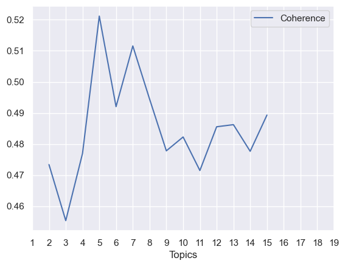

```python
lda_tuning.plot(x ='Topics', y='Coherence', kind = 'line', xticks=range(1,20))
```

```python
best_n = int(lda_tuning.sort_values(by=['Coherence'], ascending=False).head(1)['Topics'])
best_n = 11
```

```python
ldamodel = LdaMulticore(doc_term_matrix, num_topics=best_n, id2word = dictionary, passes=50, workers = num_processors-1) #3 topics
print(*ldamodel.print_topics(num_topics=best_n, num_words=10), sep='\n')
```

```
(0, '0.757*"™" + 0.192*"®" + 0.048*"â" + 0.000*"—" + 0.000*"\u200d" + 0.000*"ñ" + 0.000*"…" + 0.000*"é" + 0.000*"•" + 0.000*"·"')
(1, '1.000*"•" + 0.000*"…" + 0.000*"·" + 0.000*"™" + 0.000*"—" + 0.000*"é" + 0.000*"®" + 0.000*"ē" + 0.000*"\ufeff" + 0.000*"\u200d"')
(2, '0.423*"é" + 0.220*"ó" + 0.118*"á" + 0.115*"í" + 0.061*"ñ" + 0.060*"ú" + 0.002*"â" + 0.000*"®" + 0.000*"™" + 0.000*"—"')
(3, '0.397*"\ufeff" + 0.334*"§" + 0.140*"\x92" + 0.125*"ﬁ" + 0.000*"®" + 0.000*"—" + 0.000*"·" + 0.000*"â" + 0.000*"●" + 0.000*"️"')
(4, '0.998*"…" + 0.000*"®" + 0.000*"•" + 0.000*"—" + 0.000*"é" + 0.000*"️" + 0.000*"á" + 0.000*"´" + 0.000*"·" + 0.000*"™"')
(5, '0.999*"®" + 0.000*"•" + 0.000*"é" + 0.000*"ó" + 0.000*"á" + 0.000*"—" + 0.000*"💼" + 0.000*"™" + 0.000*"í" + 0.000*"ñ"')
(6, '1.000*"·" + 0.000*"—" + 0.000*"ē" + 0.000*"ñ" + 0.000*"\ufeff" + 0.000*"‐" + 0.000*"…" + 0.000*"•" + 0.000*"§" + 0.000*"®"')
(7, '0.739*"ǣ" + 0.243*"…" + 0.001*"®" + 0.001*"—" + 0.001*"·" + 0.001*"●" + 0.001*"™" + 0.001*"️" + 0.001*"é" + 0.001*"\u200d"')
(8, '0.833*"●" + 0.130*"ē" + 0.035*"´" + 0.000*"—" + 0.000*"™" + 0.000*"é" + 0.000*"\ufeff" + 0.000*"·" + 0.000*"\u200d" + 0.000*"®"')
(9, '0.987*"‐" + 0.001*"•" + 0.001*"—" + 0.001*"®" + 0.001*"●" + 0.001*"…" + 0.001*"\ufeff" + 0.001*"·" + 0.001*"ó" + 0.001*"í"')
(10, '0.838*"—" + 0.096*"\u200d" + 0.057*"️" + 0.008*"💼" + 0.000*"…" + 0.000*"‐" + 0.000*"§" + 0.000*"™" + 0.000*"®" + 0.000*"ē"')
```

```python
lda_display = gensimvis.prepare(ldamodel, doc_term_matrix, dictionary, sort_topics=False, mds='mmds')
pyLDAvis.display(lda_display)
```

[interactive chart not shown]

```python
def get_dominant_topic(lda_model, corpus):
    # Create a mapping from numerical identifiers to letters (A, B, C, ...)
    topic_names = {i: letter for i, letter in enumerate(string.ascii_uppercase)}

    # Get the dominant topic for each document
    topics = [max(doc, key=lambda x: x[1])[0] for doc in lda_model[corpus]]

    # Map the numerical topic identifiers to names (A, B, C, ...)
    named_topics = [topic_names[topic] if topic in topic_names else 'Beyond_Z' for topic in topics]
    return named_topics

# Assuming lda_model and corpus are already defined
job_postings['jd_topic'] = get_dominant_topic(ldamodel, doc_term_matrix)
job_postings['jd_topic'].value_counts()
```

```
jd_topic
A    27088
K     1458
F     1070
G      813
B      802
E      615
C      281
D      189
I      128
J       55
H       41
Name: count, dtype: int64
```

## Function to extract text data from the resumes:

```python
def text_extraction_from_pdf(pdf_path):

    # Function to extract text from a single PDF file
    def extract_text_from_pdf(pdf_path):
        with fitz.open(pdf_path) as doc:
            text = ""
            for page in doc:
                text += page.get_text()
        return text

    # Read the PDF and extract text from the provided path
    resume_text = extract_text_from_pdf(pdf_path)

    # Convert to lowercase for consistent matching
    resume_text = resume_text.lower()

    # Section headings in resume
    section_headings = [
        'experience', 'work experience', 'professional experience', 'work history',
        'professional background', 'employment history', 'education', 'academic background',
        'qualifications', 'projects', 'portfolio', 'skills', 'technical skills',
        'proficiencies', 'competencies', 'certifications', 'awards', 'honors',
        'publications', 'languages', 'volunteer work', 'extracurricular activities'
    ]

    # Regex pattern that matches the section headings
    section_headings_pattern = r'|'.join([re.escape(heading) for heading in section_headings])

    patterns = {
        'credentials': fr'(?i)\b(?:{section_headings_pattern})\b(.*?)(?=\n\b(?:{section_headings_pattern})\b)',
    }

    def extract_sections(text, patterns):
        sections = {}
        for key, pattern in patterns.items():
            # Use finditer to capture all occurrences of the pattern
            matches = list(re.finditer(pattern, text, re.DOTALL | re.IGNORECASE))
            if matches:
                sections[key] = [match.group(1).strip() for match in matches]
            else:
                print(f"No match found for the section: {key}")
        return sections

    # Extract sections
    extracted_sections = extract_sections(resume_text, patterns)

    processed_sections = {}

    # Iterate over each section in the extracted sections
    for section, content_list in extracted_sections.items():
        # Process each content in the list
        processed_content = [preprocess_text(content) for content in content_list if content]
        processed_sections[section] = processed_content

    credentials_dict = processed_sections
    # Join lists in credentials_dict with newline characters
    credentials_string = '\n\n'.join('\n'.join(contents) for contents in credentials_dict.values())
    extracted_text = preprocess_text(credentials_string)

    return extracted_text
```

# Modeling frameworks:

## 1. Text-based clustering using truncatedSVD on the TF-IDF matrix and using DBSCAN as a clustering technique and recommend jobs in similar clusters:

### TF-IDF:

```python
# Initialize TFIDF vectorizer
vectorizer = TfidfVectorizer(stop_words='english')

# Textual Similarity using TF-IDF on the filtered dataframe
tfidf_matrix = vectorizer.fit_transform(df1['processed_description'])
```

### Calculate the sparsity of the tfidf matrix:

```python
from scipy.sparse import issparse

print(issparse(tfidf_matrix))
```

```
True
```

### As tfidf_matrix is a sparse matrix, truncated-SVD will works the best.

```python
# Number of dimensions to reduce to
n_components = 60

# Create a Truncated SVD instance
svd = TruncatedSVD(n_components=n_components)

normalizer = Normalizer(copy=False)

lsa = make_pipeline(svd, normalizer)

# Apply LSA to the TF-IDF matrix
reduced_matrix = lsa.fit_transform(tfidf_matrix)
```

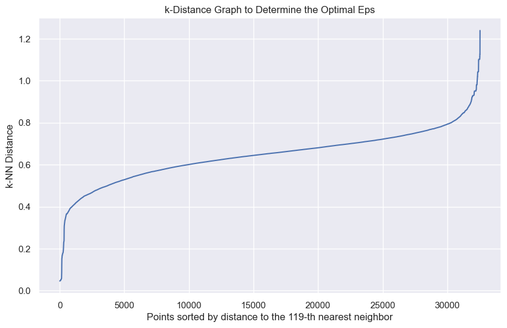

```python
# Set k to min_samples - 1
k = 120 - 1

# Compute the nearest neighbor distances
nearest_neighbors = NearestNeighbors(n_neighbors=k)
nearest_neighbors.fit(reduced_matrix)
distances, indices = nearest_neighbors.kneighbors(reduced_matrix)

# Sort the distances
sorted_distances = np.sort(distances[:, k-1], axis=0)

# Plot the k-distance graph
plt.figure(figsize=(10, 6))
plt.plot(sorted_distances)
plt.xlabel('Points sorted by distance to the {}-th nearest neighbor'.format(k))
plt.ylabel('k-NN Distance')
plt.title('k-Distance Graph to Determine the Optimal Eps')
plt.grid(True)
plt.show()
```

```python
def recommend_similar_jobs(job_title, job_postings):

    job_title = job_title.lower()

    # Filter out noise with cluster != -1
    filtered_jobs = job_postings

    # Find clusters that contain the job title exactly or closely
    clusters = filtered_jobs[filtered_jobs['title'].str.lower().str.contains(job_title)]['cluster'].unique()

    # Recommend jobs from those clusters
    similar_jobs = filtered_jobs[filtered_jobs['cluster'].isin(clusters)]

    # Optional: Sort by how closely the job titles match the search term
    similar_jobs['title_match'] = similar_jobs['title'].apply(lambda x: job_title in x.lower())
    similar_jobs = similar_jobs.sort_values('title_match', ascending=False).drop('title_match', axis=1)

    return similar_jobs[['job_id', 'title', 'company_name', 'cluster']]
```

### Case 1: eps = 0.4, min_samples = 120

```python
dbscan = DBSCAN(eps=0.4, min_samples=120)
cluster_labels = dbscan.fit_predict(reduced_matrix)
```

```python
df1['cluster'] = cluster_labels
```

```python
df1['cluster'].value_counts()
```

```
cluster
-1     29504
 2       705
 6       311
 11      234
 7       227
 3       212
 5       185
 4       177
 1       164
 9       154
 13      144
 12      138
 8       136
 0       125
 10      124
Name: count, dtype: int64
```

```python
similar_jobs_df = recommend_similar_jobs('ml engineer', df1)
similar_jobs_df.head()
```

|  | job_id | title | company_name | cluster |
| --- | --- | --- | --- | --- |
| 9713 | 3756114393 | Lead AI/ML Engineer | Raymond James | -1 |
| 5915 | 3757470473 | Mid/Senior ML Engineer | Stealth Startup | -1 |
| 30935 | 3693051645 | AI/ML Engineer - ATAS - Open Rank | Georgia Tech Research Institute | -1 |
| 31889 | 3693047544 | Data Scientists / AIML Engineer | Ztek Consulting | -1 |
| 22319 | 3699083973 | Jeweler | Signet Jewelers | -1 |

### Case 2: eps = 0.8, min_samples = 120

```python
dbscan = DBSCAN(eps=0.8, min_samples=120)
cluster_labels = dbscan.fit_predict(reduced_matrix)
```

```python
df1['cluster'] = cluster_labels
```

```python
df1['cluster'].value_counts()
```

```
cluster
 0    32245
-1      295
Name: count, dtype: int64
```

```python
similar_jobs_df = recommend_similar_jobs('ml engineer', df1)
similar_jobs_df.head(10)
```

|  | job_id | title | company_name | cluster |
| --- | --- | --- | --- | --- |
| 5915 | 3757470473 | Mid/Senior ML Engineer | Stealth Startup | 0 |
| 9713 | 3756114393 | Lead AI/ML Engineer | Raymond James | 0 |
| 31889 | 3693047544 | Data Scientists / AIML Engineer | Ztek Consulting | 0 |
| 30935 | 3693051645 | AI/ML Engineer - ATAS - Open Rank | Georgia Tech Research Institute | 0 |
| 0 | 3757940104 | Hearing Care Provider | HearingLife | 0 |
| 22170 | 3699085418 | CNC Machinist Trainee | FactoryFix | 0 |
| 22167 | 3699085475 | Welding/Mechanical Inspector | Intertek | 0 |
| 22168 | 3699085449 | Director Pharmacy and Professional Services | PeaceHealth | 0 |
| 22169 | 3699085447 | Rehab Aide - Physical Therapy Ortho | PeaceHealth | 0 |
| 22172 | 3699085414 | Administrative Assistant \| Property & Casualty | CBIZ | 0 |

```python
similar_jobs_df = recommend_similar_jobs('need a ml engineer', df1)
similar_jobs_df.head()
```

|  | job_id | title | company_name | cluster |
| --- | --- | --- | --- | --- |

### In this technique only we can perform keyword search and if the title does not contain our required job it won't give any recommendations. More robust technique will be to apply NLP techniques on the job description data to recommend similar jobs. Also, the clustering based recommendation does not give good recommendations. Also, more NLP techniques can handle more complicated inputs like text mined from resume pdfs and so on.

## 2. Job Recommendation based on TF-IDF and cosine similarity:

```python
def recommend_jobs_tcs(candidate_profile, df, desired_work_type=None, a = (1,1)):

    # Function to format the work type
    def format_work_type(work_type):
        # Remove non-alphanumeric characters and convert to lower case
        return re.sub(r'\W+', '', work_type).lower()

    # Filter the dataframe based on a flexible work type matching
    if desired_work_type is not None:
        desired_work_type_formatted = format_work_type(desired_work_type)
        df = df[df['formatted_work_type'].apply(format_work_type) == desired_work_type_formatted]

    # Check if there are any jobs left after filtering
    if df.empty:
        print("No jobs found matching the specified work type.")
        return pd.DataFrame()

    #Initialize TFIDF vectorizer
    vectorizer = TfidfVectorizer(stop_words='english', ngram_range = a)

    # Textual Similarity using TF-IDF on the filtered dataframe
    tfidf_matrix = vectorizer.fit_transform(df['processed_description'])

    # Transform the candidate's profile using the same vectorizer
    candidate_vector = vectorizer.transform([candidate_profile])

    # Compute cosine similarity between candidate's profile and job descriptions
    cosine_similarities = linear_kernel(candidate_vector, tfidf_matrix).flatten()

    # Get indices of jobs sorted by similarity
    sorted_job_indices = cosine_similarities.argsort()[::-1]

    top_job_indices = sorted_job_indices[:min(10, len(sorted_job_indices))]

    # Select the top similar jobs
    top_jobs = df.iloc[top_job_indices]

    # Add the similarity score to the DataFrame
    top_jobs['similarity_score'] = cosine_similarities[top_job_indices]

    # Group by title and company_name and take the first entry from each group to avoid duplicates
    top_jobs_unique = top_jobs.groupby(['title', 'company_name']).head(1)

    # Sort the unique jobs based on similarity score
    top_jobs_unique_sorted = top_jobs_unique.sort_values(by=['similarity_score'], ascending=[False])

    # Return the top unique sorted jobs
    return top_jobs_unique_sorted[['title', 'company_name', 'job_posting_url']]
```

```python
candidate_profile = 'ml engineer'
desired_work_type = "full time"
recommended_jobs_tcs = recommend_jobs_tcs(candidate_profile, df1, desired_work_type , (1, 2))
recommended_jobs_tcs
```

|  | title | company_name | job_posting_url |
| --- | --- | --- | --- |
| 9713 | Lead AI/ML Engineer | Raymond James | https://www.linkedin.com/jobs/view/3756114393/... |
| 29716 | Machine Learning Engineer | Smarxion | https://www.linkedin.com/jobs/view/3693067630/... |
| 11953 | AI Architect | Apptad Inc. | https://www.linkedin.com/jobs/view/3755586318/... |
| 25778 | ML Infrastructure Team Lead | Storm3 | https://www.linkedin.com/jobs/view/3694163111/... |
| 25787 | Principal MLOps Engineer | Storm3 | https://www.linkedin.com/jobs/view/3694161427/... |
| 27193 | Senior ML Specialist Solutions Architect, ML S... | Amazon Web Services (AWS) | https://www.linkedin.com/jobs/view/3694102195/... |
| 5915 | Mid/Senior ML Engineer | Stealth Startup | https://www.linkedin.com/jobs/view/3757470473/... |
| 27072 | Head of Engineering | Spice AI | https://www.linkedin.com/jobs/view/3694103033/... |
| 28530 | Principal Product Manager | UKG | https://www.linkedin.com/jobs/view/3693583948/... |
| 23409 | Machine Learning Engineer - Notifications | Nextdoor | https://www.linkedin.com/jobs/view/3698000140/... |

### Test 1: Text from resume of person 1 with experience in finance:

```python
candidate_profile = text_extraction_from_pdf(r"C:\Users\nihar\Desktop\RESUME\Resume1.pdf")
desired_work_type = "full time"
recommended_jobs_tcs = recommend_jobs_tcs(candidate_profile, df1, desired_work_type, (1, 2))
recommended_jobs_tcs[['title', 'company_name']]
```

|  | title | company_name |
| --- | --- | --- |
| 6731 | Senior Trader | T3 Global |
| 7033 | Proprietary Trader | T3 Global |
| 12028 | Experienced Trader | T3 Trading Group |
| 6624 | Market Maker | T3 Global |
| 12287 | Proprietary Trader | T3 Trading Group |
| 6540 | Derivatives Trader | T3 Global |
| 28962 | Product Manager - Trading Technology | Quantitative Systems |

### Test 2: Text from resume of person 2 with experience in nlp and machine learning:

```python
candidate_profile = text_extraction_from_pdf(r"C:\Users\nihar\Desktop\RESUME\Resume2.pdf")
desired_work_type = "full time"
recommended_jobs_tcs = recommend_jobs_tcs(candidate_profile, df1, desired_work_type, (1, 2))
recommended_jobs_tcs
```

|  | title | company_name | job_posting_url |
| --- | --- | --- | --- |
| 6593 | Data Scientist | NLB Services | https://www.linkedin.com/jobs/view/3757461432/... |
| 24693 | Machine Learning Scientist I | Cambia Health Solutions | https://www.linkedin.com/jobs/view/3697379856/... |
| 7084 | Machine Learning Engineer - $175k+ | Henderson Harbor Group | https://www.linkedin.com/jobs/view/3757454354/... |
| 27193 | Senior ML Specialist Solutions Architect, ML S... | Amazon Web Services (AWS) | https://www.linkedin.com/jobs/view/3694102195/... |
| 26107 | Natural Language Processing (NLP) Data Scientist. | My Working Soul | https://www.linkedin.com/jobs/view/3694121166/... |
| 4282 | Principal NLP Data Scientist | WEX | https://www.linkedin.com/jobs/view/3757492660/... |
| 28721 | Senior Data Scientist | Genentech | https://www.linkedin.com/jobs/view/3693581630/... |
| 4526 | Data Scientist | Dotdash Meredith | https://www.linkedin.com/jobs/view/3757490630/... |

### Test 3: Text from resume of person 3 with experience in marketing data analyst/scientist:

```python
candidate_profile = text_extraction_from_pdf(r"C:\Users\nihar\Desktop\RESUME\Resume3.pdf")
desired_work_type = "full time"
recommended_jobs_tcs = recommend_jobs_tcs(candidate_profile, df1, desired_work_type, (1, 2))
recommended_jobs_tcs
```

|  | title | company_name | job_posting_url |
| --- | --- | --- | --- |
| 6010 | Next Generation Data Analyst (On-site, NYC) | DXC Technology | https://www.linkedin.com/jobs/view/3757469023/... |
| 7299 | Data Scientist - $175k+ | Henderson Harbor Group | https://www.linkedin.com/jobs/view/3757450438/... |
| 9842 | Director Data Science | WITHIN | https://www.linkedin.com/jobs/view/3756113091/... |
| 31549 | Marketing Analytics Manager | Soni | https://www.linkedin.com/jobs/view/3693048936/... |
| 31379 | Senior Manager | InnoActive Group | https://www.linkedin.com/jobs/view/3693049684/... |
| 9577 | Senior Manager/Director Media Mix Modeling (MMM) | Blend | https://www.linkedin.com/jobs/view/3756116606/... |
| 11089 | Senior Content Syndication Manager, Paid Media | Jellyfish | https://www.linkedin.com/jobs/view/3755594939/... |
| 11222 | Senior Content Syndication Manager | Jellyfish | https://www.linkedin.com/jobs/view/3755593541/... |
| 17867 | Associate Manager, Digital Media, eComm - Acti... | Walmart | https://www.linkedin.com/jobs/view/3701362867/... |

### Test 4: Text from resume of person 4 with experience in consulting, venture capital/entrepreneurship:

```python
candidate_profile = text_extraction_from_pdf(r"C:\Users\nihar\Desktop\RESUME\Resume4.pdf")
desired_work_type = "full time"
recommended_jobs_tcs = recommend_jobs_tcs(candidate_profile, df1, desired_work_type, (1,2))
recommended_jobs_tcs
```

|  | title | company_name | job_posting_url |
| --- | --- | --- | --- |
| 18481 | Senior Financial Analyst, FP&A | Turn2Partners | https://www.linkedin.com/jobs/view/3701321032/... |
| 32890 | Vice President of Growth & Strategy | KORB Health Group | https://www.linkedin.com/jobs/view/3692363921/... |
| 22202 | Healthcare Operations Specialist, Nursing Reso... | University of Illinois Chicago | https://www.linkedin.com/jobs/view/3699085166/... |
| 25411 | Associate Director, Global Decision Sciences &... | Gilead Sciences | https://www.linkedin.com/jobs/view/3697354560/... |
| 20091 | Investment Associate | Spencer Ogden | https://www.linkedin.com/jobs/view/3701199582/... |
| 25991 | Commercial Analyst – North America | Manuka Health | https://www.linkedin.com/jobs/view/3694135813/... |
| 28966 | Associate | Expert Dojo | https://www.linkedin.com/jobs/view/3693073286/... |
| 20108 | Operations Associate | S2G Ventures | https://www.linkedin.com/jobs/view/3701199275/... |
| 3306 | Investor Relations Analyst | Coda Search│Staffing | https://www.linkedin.com/jobs/view/3757707396/... |
| 2489 | Director of Food & Beverage | CoralTree Hospitality | https://www.linkedin.com/jobs/view/3757731963/... |

## TFIDF (unigram) + Cosine Similarity:

```python
candidate_profile = text_extraction_from_pdf(r"C:\Users\nihar\Desktop\RESUME\Resume2.pdf")
desired_work_type = "full time"
recommended_jobs_tcs = recommend_jobs_tcs(candidate_profile, df1, desired_work_type, (1, 1))
recommended_jobs_tcs
```

|  | title | company_name | job_posting_url |
| --- | --- | --- | --- |
| 24693 | Machine Learning Scientist I | Cambia Health Solutions | https://www.linkedin.com/jobs/view/3697379856/... |
| 4282 | Principal NLP Data Scientist | WEX | https://www.linkedin.com/jobs/view/3757492660/... |
| 15625 | Python Data Engineer (AWS) | TalentOla | https://www.linkedin.com/jobs/view/3749351208/... |
| 26107 | Natural Language Processing (NLP) Data Scientist. | My Working Soul | https://www.linkedin.com/jobs/view/3694121166/... |
| 28721 | Senior Data Scientist | Genentech | https://www.linkedin.com/jobs/view/3693581630/... |
| 6593 | Data Scientist | NLB Services | https://www.linkedin.com/jobs/view/3757461432/... |
| 29687 | Assistant Vice President, Quantitative Finance... | Bank of America | https://www.linkedin.com/jobs/view/3693067787/... |
| 7084 | Machine Learning Engineer - $175k+ | Henderson Harbor Group | https://www.linkedin.com/jobs/view/3757454354/... |

## TFIDF (bigram) + Cosine Similarity:

```python
candidate_profile = text_extraction_from_pdf(r"C:\Users\nihar\Desktop\RESUME\Resume2.pdf")
desired_work_type = "full time"
recommended_jobs_tcs = recommend_jobs_tcs(candidate_profile, df1, desired_work_type, (2, 2))
recommended_jobs_tcs
```

|  | title | company_name | job_posting_url |
| --- | --- | --- | --- |
| 7084 | Machine Learning Engineer - $175k+ | Henderson Harbor Group | https://www.linkedin.com/jobs/view/3757454354/... |
| 6593 | Data Scientist | NLB Services | https://www.linkedin.com/jobs/view/3757461432/... |
| 27193 | Senior ML Specialist Solutions Architect, ML S... | Amazon Web Services (AWS) | https://www.linkedin.com/jobs/view/3694102195/... |
| 26107 | Natural Language Processing (NLP) Data Scientist. | My Working Soul | https://www.linkedin.com/jobs/view/3694121166/... |
| 6990 | Machine Learning Engineer | 2FST.CO | https://www.linkedin.com/jobs/view/3757456874/... |
| 25780 | Director, Machine Learning Platform | Storm3 | https://www.linkedin.com/jobs/view/3694163107/... |

## TFIDF (unigram + bigram) + Cosine Similarity:

```python
candidate_profile = text_extraction_from_pdf(r"C:\Users\nihar\Desktop\RESUME\Resume2.pdf")
desired_work_type = "full time"
recommended_jobs_tcs = recommend_jobs_tcs(candidate_profile, df1, desired_work_type, (1, 2))
recommended_jobs_tcs
```

|  | title | company_name | job_posting_url |
| --- | --- | --- | --- |
| 6593 | Data Scientist | NLB Services | https://www.linkedin.com/jobs/view/3757461432/... |
| 24693 | Machine Learning Scientist I | Cambia Health Solutions | https://www.linkedin.com/jobs/view/3697379856/... |
| 7084 | Machine Learning Engineer - $175k+ | Henderson Harbor Group | https://www.linkedin.com/jobs/view/3757454354/... |
| 27193 | Senior ML Specialist Solutions Architect, ML S... | Amazon Web Services (AWS) | https://www.linkedin.com/jobs/view/3694102195/... |
| 26107 | Natural Language Processing (NLP) Data Scientist. | My Working Soul | https://www.linkedin.com/jobs/view/3694121166/... |
| 4282 | Principal NLP Data Scientist | WEX | https://www.linkedin.com/jobs/view/3757492660/... |
| 28721 | Senior Data Scientist | Genentech | https://www.linkedin.com/jobs/view/3693581630/... |
| 4526 | Data Scientist | Dotdash Meredith | https://www.linkedin.com/jobs/view/3757490630/... |

## 3. Job Recommendation based on CountVectorizer and cosine similarity:

```python
def recommend_jobs_ccs(candidate_profile, df, skill_bank, desired_work_type=None, a = (1, 1)):

    # Function to format the work type
    def format_work_type(work_type):
        # Remove non-alphanumeric characters and convert to lower case
        return re.sub(r'\W+', '', work_type).lower()

    # Filter the dataframe based on a flexible work type matching
    if desired_work_type is not None:
        desired_work_type_formatted = format_work_type(desired_work_type)
        df = df[df['formatted_work_type'].apply(format_work_type) == desired_work_type_formatted]

    # Check if there are any jobs left after filtering
    if df.empty:
        print("No jobs found matching the specified work type.")
        return pd.DataFrame()

    # Initialize the CountVectorizer
    vectorizer = CountVectorizer(ngram_range = a)

    # Textual Similarity using CountVectorizer on the filtered dataframe
    count_matrix = vectorizer.fit_transform(df['processed_description'])

    # Transform the candidate's profile using the same vectorizer
    candidate_vector = vectorizer.transform([candidate_profile])

    # Compute cosine similarity between candidate's profile and job descriptions
    cosine_similarities = cosine_similarity(candidate_vector, count_matrix).flatten()

    # Get indices of jobs sorted by cosine similarity
    sorted_job_indices_cosine = cosine_similarities.argsort()[::-1]

    top_job_indices = sorted_job_indices_cosine[:min(5, len(sorted_job_indices_cosine))]

    # Select the top similar jobs
    top_jobs = df.iloc[top_job_indices]

    top_jobs['similarity_score'] = cosine_similarities[top_job_indices]

    # Sort the jobs based on similarity score
    top_jobs = top_jobs.sort_values(by=['similarity_score'], ascending=False)

    return top_jobs[['title', 'company_name']]
```

```python
candidate_profile = 'ml engineer'
desired_work_type = "full time"
recommended_jobs_ccs = recommend_jobs_ccs(candidate_profile, df1, desired_work_type, a= (1, 2))
recommended_jobs_ccs
```

|  | title | company_name |
| --- | --- | --- |
| 4779 | Improvement Engineer | CPS, Inc. |
| 21860 | Engineers - Electro-Optical Imaging and Sensor... | The Photonics Group |
| 29716 | Machine Learning Engineer | Smarxion |
| 4124 | Process Engineer | CPS, Inc. |
| 9713 | Lead AI/ML Engineer | Raymond James |

## Count Vectorizer (unigram) + Cosine Similarity:

```python
candidate_profile = text_extraction_from_pdf(r"C:\Users\nihar\Desktop\RESUME\Resume2.pdf")
desired_work_type = "full time"
recommended_jobs_ccs = recommend_jobs_ccs(candidate_profile, df1, desired_work_type, a= (1, 1))
recommended_jobs_ccs
```

|  | title | company_name |
| --- | --- | --- |
| 4848 | Senior Data Scientist | TechEra Global Inc |
| 4526 | Data Scientist | Dotdash Meredith |
| 24807 | Machine Learning Scientist I | Cambia Health Solutions |
| 24693 | Machine Learning Scientist I | Cambia Health Solutions |
| 31889 | Data Scientists / AIML Engineer | Ztek Consulting |

## Count Vectorizer (bigram) + Cosine Similarity:

```python
candidate_profile = text_extraction_from_pdf(r"C:\Users\nihar\Desktop\RESUME\Resume2.pdf")
desired_work_type = "full time"
recommended_jobs_ccs = recommend_jobs_ccs(candidate_profile, df1, desired_work_type, a= (2, 2))
recommended_jobs_ccs
```

|  | title | company_name |
| --- | --- | --- |
| 7084 | Machine Learning Engineer - $175k+ | Henderson Harbor Group |
| 6593 | Data Scientist | NLB Services |
| 20145 | Mentor - Machine Learning Career Track (Part-t... | Springboard |
| 25780 | Director, Machine Learning Platform | Storm3 |
| 16829 | Machine Learning Engineer | 2FST.CO |

## Count vectorizer (unigram + bigram) + Cosine Similarity:

```python
candidate_profile = text_extraction_from_pdf(r"C:\Users\nihar\Desktop\RESUME\Resume2.pdf")
desired_work_type = "full time"
recommended_jobs_ccs = recommend_jobs_ccs(candidate_profile, df1, desired_work_type, a= (1, 2))
recommended_jobs_ccs
```

|  | title | company_name |
| --- | --- | --- |
| 4526 | Data Scientist | Dotdash Meredith |
| 6593 | Data Scientist | NLB Services |
| 24807 | Machine Learning Scientist I | Cambia Health Solutions |
| 24693 | Machine Learning Scientist I | Cambia Health Solutions |
| 28508 | Senior Data Scientist | Genentech |